Correlogram

definition - mistake - related - code

# Definition

A `correlogram` or correlation matrix allows to analyse the relationship between each pair of numeric variables of a dataset. The relationship between each pair of variable is visualised through a [scatterplot](http://www.data-to-viz.com/graph/scatter.html), or a symbol that represents the correlation (bubble, line, number..).

The diagonal often represents the `distribution` of each variable, using an [histogram](http://www.data-to-viz.com/graph/histogram.html) or a [density plot](http://www.data-to-viz.com/graph/density.html).

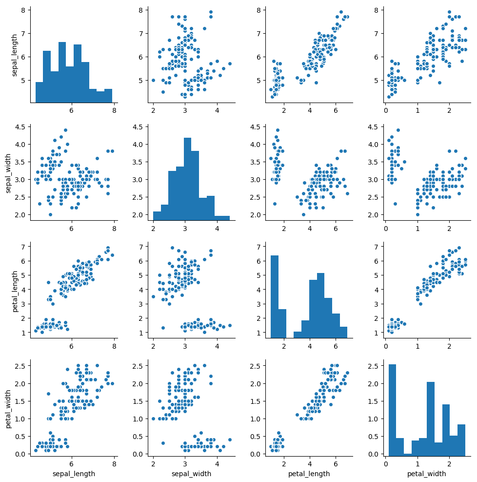

```python
# library & dataset
import seaborn as sns
df = sns.load_dataset('iris')
import matplotlib.pyplot as plt

# Basic correlogram
sns_plot = sns.pairplot(df)
sns_plot.savefig("IMG/correlogram1.png")
```

*Note*: exceptionally, graphic provided in this page are made with [Python](https://python-graph-gallery.com/correlogram/), since I really like the `pairplot` function of the [seaborn library](https://python-graph-gallery.com/correlogram/).

# What for

Correlogram are really handy for `exploratory analysis`. It allows to visualize the relationships of the whole dataset in a glimpse. For instance, the linear relationship between petal length and petal width is obvious here, as the one concerning sepal.

When you get a multivariate dataset, building a correlogram is one of the first step you should follow.

# Variation

All the variations described in the [scatterplot](http://www.data-to-viz.com/graph/scatter.html) section are also available for correlogram. For example, why not applying a linear regression to each pair of variable:

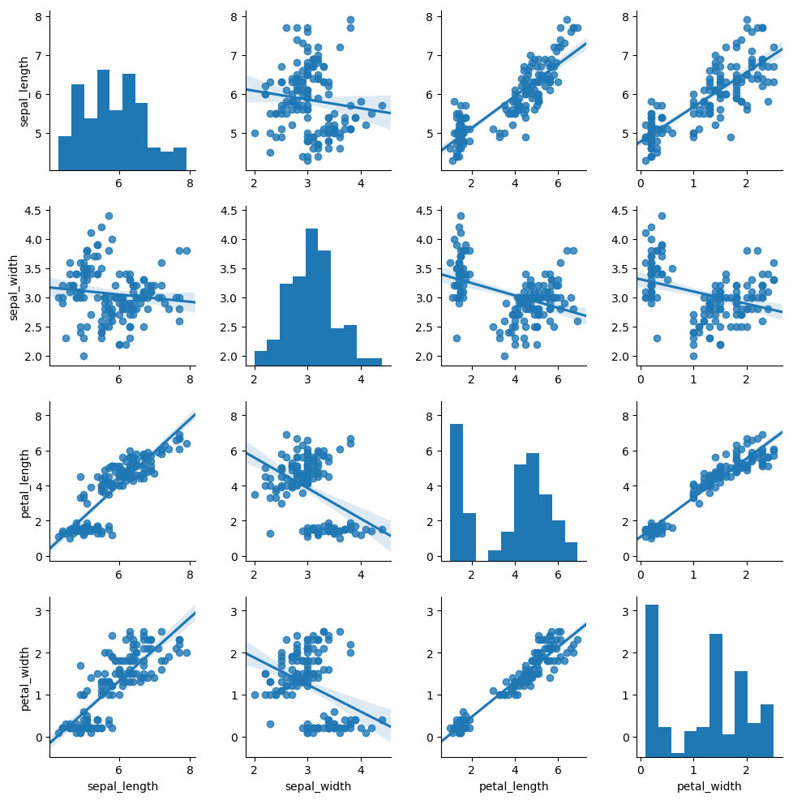

```python
# with regression
sns_plot = sns.pairplot(df, kind="reg")
sns_plot.savefig("IMG/correlogram2.png")
```

As described in the scatterplot section, it is a good practice to display subgroups if a categoric variable is available as well:

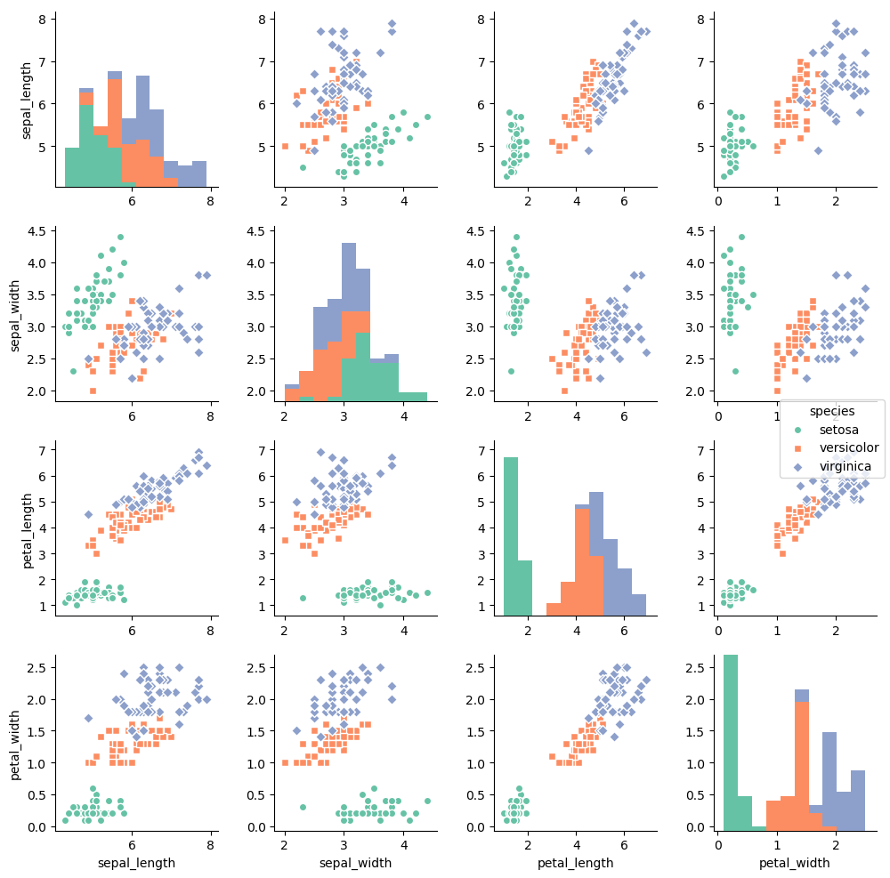

```python
# with regression
sns_plot = sns.pairplot(df, kind="scatter", hue="species", markers=["o", "s", "D"], palette="Set2")
sns_plot.savefig("IMG/correlogram3.png")
```

# Common mistakes

- Displaying the relationship between more than ~10 variables makes the plot very hard to read
- All the common caveats of [scatterplot](http://www.data-to-viz.com/graph/scatter.html) and [histogram](http://www.data-to-viz.com/graph/histogram.html) apply

# Related

Bubble plot

Add a third dimension to your scatter: the circle size

Scatter plot

Display the relationship between 2 numeric variables

Connected Scatterplot

Very close from a scatterplot, but link data points with segments

Density 2d

One of the best way to avoid overplotting for big sample size

# Build your own

The [R](https://www.r-graph-gallery.com) and [Python](https://www.python-graph-gallery.com) graph galleries are 2 websites providing hundreds of chart example, always providing the reproducible code. Click the button below to see how to build the chart you need with your favorite programing language.

[R graph gallery](https://www.r-graph-gallery.com/correlogram/) [Python gallery](https://python-graph-gallery.com/correlogram/)

# Comments

Any thoughts on this? Found any mistake? Disagree? Please drop me a word on [twitter](https://twitter.com/R_Graph_Gallery) or in the comment section below:

A work by [Yan Holtz](https://github.com/holtzy/) for data-to-viz.com